# CPUE standardization

Beth Babcock

2024-07-03

Although the model was originally developed for bycatch estimation, it can also produce a CPUE index of abundance. For this exercise we will turn off bycatch estimation. We will use the LLSIM blue marlin data. The following models will show how to:

1. Compare model types.
2. Add random effects
3. Add more variables.

```r
# devtools::install_github("ebabcock/BycatchEstimator")  #Make sure library is installed
library(BycatchEstimator)
library(MuMIn)
library(tidyverse)
```

Model fitting and model selection can be slow. So, for the purposes of this demonstration, we will limit the data to a 15 year period so it will run faster.

```r
obsdatTest<-filter(LLSIM_BUM_Example_observer,Year %in% 2001:2015)
logdatTest<-filter(LLSIM_BUM_Example_logbook,Year %in% 2001:2015)
```

1. Compare model types.

```r
setupObj<-bycatchSetup(
 modelTry = c("TMBdelta-Lognormal","TMBdelta-Gamma","TMBnbinom2","TMBtweedie"), #model types to compare
 obsdat = obsdatTest,
  logdat = NULL,
  yearVar = "Year",
  obsEffort = "hooks",
  logEffort = "hooks",
  factorNames = c("Year","season","area"),
  EstimateIndex = TRUE,
  EstimateBycatch = FALSE,
  logNum=NULL,
  sampleUnit = "trips",
  complexModel = formula(y~Year+season+area+fleet +area:season), #upper range of models to compare with information criteria,
  simpleModel = formula(y~Year), #lower range of models to compare
  indexModel = formula(y~Year+area), #Variables to include in index.
  designMethods ="None",
  baseDir = getwd(),
  runName = "LLSIMBUMCPUE1",
  runDescription = "LLSIm BUM CPUE",
  common = "Blue marlin",
  sp = "Makaira nigricans",
  obsCatch = "BUM",
  catchUnit = "number",
  catchType = "catch"
)
```

bycatchFit doesn’t need any changes.

```r
bycatchFit(
  setupObj,
  selectCriteria = "BIC",
  DoCrossValidation = TRUE,
  DredgeCrossValidation = FALSE,
  ResidualTest = FALSE,
  CIval = 0.05,
  VarCalc = "DeltaMethod",
  useParallel = TRUE,  #Make this FALSE if parallel processing doesn't work.
  nSims = 100,
  baseDir = getwd(),
)
```

```
## [1] "1 Blue marlin complete,  2024-07-03 09:02:48.434205"
```

Now, looking at the output .pdf, there will be no total bycatch estimates, but there will be abundance indices plotted, plus and minus a standard error. The data are also in a .csv file.

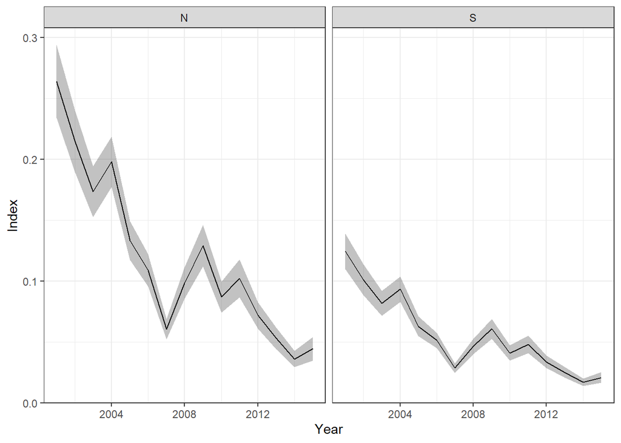

```r
nbinom2Index<-read.csv("Output LLSIMBUMCPUE1/Blue marlin catch/Blue marlincatchTMBnbinom2Index.csv")
ggplot(nbinom2Index,aes(x=Year,y=Index,ymin=ymin,ymax=ymax))+
  geom_line()+
  geom_ribbon(alpha=0.3)+
  facet_wrap(area~.)
```

2. Add random effects

CPUE standardization models commonly include random effects, for example to handle interactions between Year and other variables. It is also worthwhile to include fishing vessel as a random effect when using sets as a sample unit, to deal with the clumping in the data. Let’s try Year:area as a random effect. Of course, random effects can also be used for bycatch estimation, but this is less commonly done. If random effects are included, they will be automatically included in all models. randomEffects is the list of random effects to include in the model. For delta models, randomEffects2 can be used to give a different set of randomEffects for the two model components.

```r
setupObj<-bycatchSetup(
 modelTry = c("TMBdelta-Lognormal","TMBnbinom1","TMBdelta-Gamma","TMBnbinom2","TMBtweedie"), #model types to compare
 obsdat = obsdatTest,
  logdat = NULL,
  yearVar = "Year",
  obsEffort = "hooks",
  logEffort = "hooks",
  factorNames = c("Year","season","area"),
  randomEffects = c("Year:area"),
  randomEffects2 = c("Year:area"),
  EstimateIndex = TRUE,
  EstimateBycatch = FALSE,
  logNum=NULL,
  sampleUnit = "trips",
  complexModel = formula(y~Year+season+area+fleet +area:season), #upper range of models to compare with information criteria, fixed effects only.
  simpleModel = formula(y~Year), #lower range of models to compare, fixed effects only
  indexModel = formula(y~Year+area), #Variables to include in index.
  designMethods ="None",
  baseDir = getwd(),
  runName = "LLSIMBUMCPUE2",
  runDescription = "LLSIm BUM CPUE with Year:area",
  common = "Blue marlin",
  sp = "Makaira nigricans",
  obsCatch = "BUM",
  catchUnit = "number",
  catchType = "catch"
)
```

```r
bycatchFit(
  setupObj,
  selectCriteria = "BIC",
  DoCrossValidation = TRUE,
  DredgeCrossValidation = FALSE,
  ResidualTest = FALSE,
  CIval = 0.05,
  VarCalc = "DeltaMethod",
  useParallel = TRUE,  #Make this FALSE if parallel processing doesn't work.
  nSims = 100,
  baseDir = getwd(),
)
```

```
## Fixed terms are "cond(Year)", "cond((Int))" and "disp((Int))"
```

```
## Fixed terms are "cond(Year)", "cond(offset(log(Effort)))", "cond((Int))" and "disp((Int))"
## Fixed terms are "cond(Year)", "cond(offset(log(Effort)))", "cond((Int))" and "disp((Int))"
```

```
## Fixed terms are "cond(Year)", "cond((Int))" and "disp((Int))"
## Fixed terms are "cond(Year)", "cond((Int))" and "disp((Int))"
## Fixed terms are "cond(Year)", "cond((Int))" and "disp((Int))"
```

```
## DHARMa:testOutliers with type = binomial may have inflated Type I error rates for integer-valued distributions. To get a more exact result, it is recommended to re-run testOutliers with type = 'bootstrap'. See ?testOutliers for details
```

```
## [1] "1 Blue marlin complete,  2024-07-03 09:08:32.315712"
```

3. Add more variables.

For CPUE standardization, it may be desirable to add more variables, such as gear variables and environmental variables. Numerical variables will be set to their mean for the prediction. Here we add two numerical variables (hbf and habBUM) and more factors (light).

```r
setupObj<-bycatchSetup(
 modelTry = c("TMBdelta-Lognormal","TMBnbinom1","TMBdelta-Gamma","TMBnbinom2","TMBtweedie"), #model types to compare
 obsdat = obsdatTest,
  logdat = NULL,
  yearVar = "Year",
  obsEffort = "hooks",
  logEffort = "hooks",
  factorNames = c("Year","season","area","light"),
  randomEffects = NULL,
  randomEffects2 = NULL,
  EstimateIndex = TRUE,
  EstimateBycatch = FALSE,
  logNum=NULL,
  sampleUnit = "trips",
  complexModel = formula(y~Year+season+area+fleet +light+hbf+habBUM), #upper range of models to compare with information criteria, fixed effects only.
  simpleModel = formula(y~Year), #lower range of models to compare, fixed effects only
  indexModel = formula(y~Year+area), #Variables to include in index.
  designMethods ="None",
  baseDir = getwd(),
  runName = "LLSIMBUMCPUE3",
  runDescription = "LLSIm BUM CPUE more variables",
  common = "Blue marlin",
  sp = "Makaira nigricans",
  obsCatch = "BUM",
  catchUnit = "number",
  catchType = "catch"
)
```

```r
bycatchFit(
  setupObj,
  selectCriteria = "BIC",
  DoCrossValidation = TRUE,
  DredgeCrossValidation = FALSE,
  ResidualTest = FALSE,
  CIval = 0.05,
  VarCalc = "DeltaMethod",
  useParallel = TRUE,  #Make this FALSE if parallel processing doesn't work.
  nSims = 100,
  baseDir = getwd(),
)
```

```
## [1] "1 Blue marlin complete,  2024-07-03 09:12:52.871547"
```